# Session07: Transformations — MULTI2110

Mazunki Hoksaas

2023-10-14

# Homework

We will be using the nettle dataset again.

## (a1) transforming the data

```
##    Country            Population         Area            MGS
##  Length:74          Min.   :2.010   Min.   :4.090   Min.   : 0.000
##  Class :character   1st Qu.:3.607   1st Qu.:5.223   1st Qu.: 5.348
##  Mode  :character   Median :3.990   Median :5.640   Median : 7.355
##                     Mean   :3.992   Mean   :5.618   Mean   : 7.029
##                     3rd Qu.:4.393   3rd Qu.:6.032   3rd Qu.: 9.193
##                     Max.   :5.930   Max.   :6.930   Max.   :12.000
##      Langs           raw_area       raw_population
##  Min.   :  1.00   Min.   :  12303   Min.   :   102329
##  1st Qu.: 17.25   1st Qu.: 167128   1st Qu.:  4052253
##  Median : 40.00   Median : 437558   Median :  9774963
##  Mean   : 89.73   Mean   : 882309   Mean   : 33707277
##  3rd Qu.: 93.75   3rd Qu.:1078182   3rd Qu.: 24747372
##  Max.   :862.00   Max.   :8511380   Max.   :851138038
```

### (a2) modelling the data, plotting

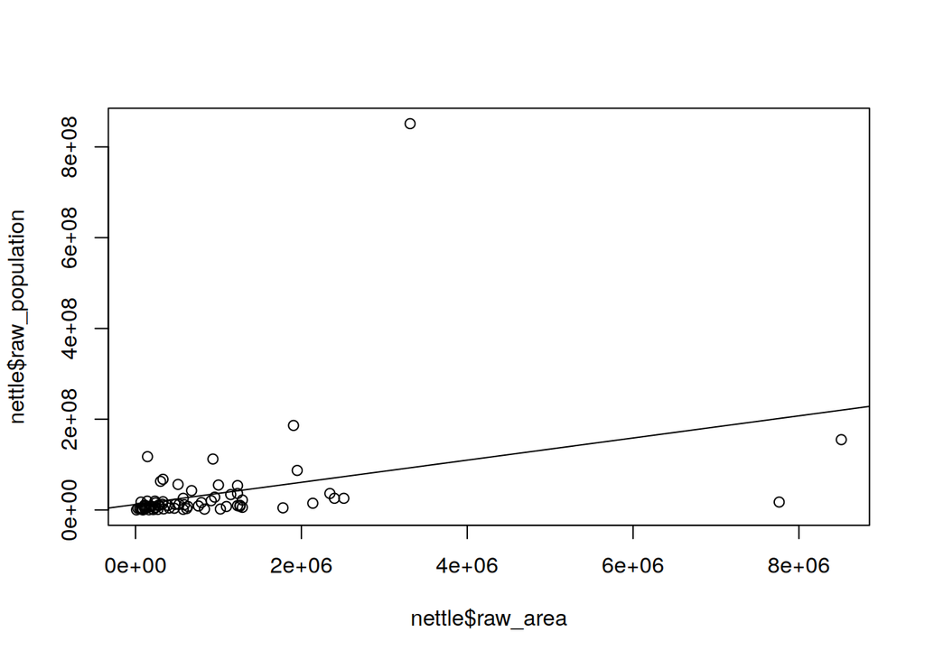

personally i prefer to visualize the logarithmic values, since the data doesn’t conglomerate into a corner

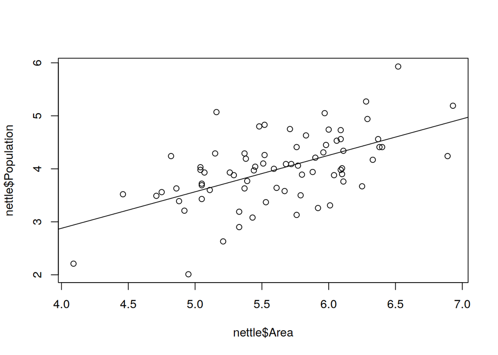

## (b) inspecting the model

```
##
## Call:
## lm(formula = raw_population ~ raw_area, data = nettle)
##
## Residuals:
##        Min         1Q     Median         3Q        Max
## -184265078  -19803771  -11617744   -5446450  758141977
##
## Coefficients:
##              Estimate Std. Error t value Pr(>|t|)
## (Intercept) 1.217e+07  1.336e+07   0.911  0.36523
## raw_area    2.441e+01  8.097e+00   3.015  0.00355 **
## ---
## Signif. codes:  0 '***' 0.001 '**' 0.01 '*' 0.05 '.' 0.1 ' ' 1
##
## Residual standard error: 97090000 on 72 degrees of freedom
## Multiple R-squared:  0.1121, Adjusted R-squared:  0.09974
## F-statistic: 9.088 on 1 and 72 DF,  p-value: 0.003552
```

the intercept is the expected population when the area is at zero, and show up to be at 12M. it doesn’t make much sense to have 12M people living in zero square meters, but it does give an intuition of how many people would need to come together to form a country.

## (c) centering the raw data

we shifted all the areas by the mean of the area, meaning an area of zero is equivalent to the mean, and we’ll have negative areas for those areas which were under the mean. by doing this, we’ve managed to lower the standard deviation to 11M instead (although i can’t say i fully understand how simply shifting the values causes the standard error to become lower (or minimal?)).

## (d) reinterpreting the model

```
##
## Call:
## lm(formula = raw_population ~ centered_raw_area, data = nettle)
##
## Residuals:
##        Min         1Q     Median         3Q        Max
## -184265078  -19803771  -11617744   -5446450  758141977
##
## Coefficients:
##                    Estimate Std. Error t value Pr(>|t|)
## (Intercept)       3.371e+07  1.129e+07   2.987  0.00385 **
## centered_raw_area 2.441e+01  8.097e+00   3.015  0.00355 **
## ---
## Signif. codes:  0 '***' 0.001 '**' 0.01 '*' 0.05 '.' 0.1 ' ' 1
##
## Residual standard error: 97090000 on 72 degrees of freedom
## Multiple R-squared:  0.1121, Adjusted R-squared:  0.09974
## F-statistic: 9.088 on 1 and 72 DF,  p-value: 0.003552
```

since we’ve centered the data on the its area, we can now see the intercept at 33.7M instead. this means we can expect roughly ~33M people to live in a country given a country with an average area. since the standard error is now relatively smaller than the estimate for the intercept, the t-value increases (suggesting we can be more confident when discussing an average sized country)

## (e) checking the residuals

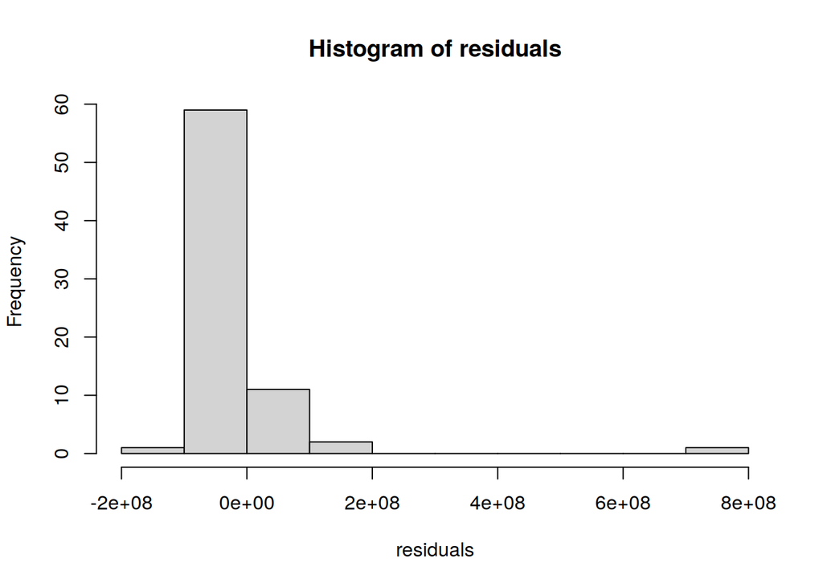

## (f) ignoring a single outlier

```
##  [1] "India"            "Australia"        "Indonesia"        "Bangladesh"
##  [5] "Nigeria"          "Brazil"           "Libya"            "Saudi Arabia"
##  [9] "Sudan"            "Vietnam"          "Algeria"          "Philippines"
## [13] "Chad"             "Mauritania"       "Niger"            "Zaire"
## [17] "Angola"           "Mali"             "Thailand"         "Bolivia"
## [21] "Namibia"          "Mexico"           "Botswana"         "CAR"
## [25] "Zambia"           "Peru"             "Somalia"          "Papua New Guinea"
## [29] "Egypt"            "Congo"            "Paraguay"         "Gabon"
## [33] "Guyana"           "Oman"             "Suriname"         "Mozambique"
## [37] "Madagascar"       "French Guiana"    "Venezuela"        "Myanmar"
## [41] "Laos"             "Yemen"            "UAE"              "Vanuatu"
## [45] "Guinea"           "Liberia"          "Zimbabwe"         "Panama"
## [49] "Cameroon"         "Ethiopia"         "Nicaragua"        "Costa Rica"
## [53] "Benin"            "Togo"             "Sierra Leone"     "Honduras"
## [57] "Solomon Islands"  "Burkina Faso"     "Senegal"          "Cambodia"
## [61] "Ecuador"          "Cote d'Ivoire"    "Tanzania"         "Malawi"
## [65] "Colombia"         "South Africa"     "Guatemala"        "Cuba"
## [69] "Nepal"            "Sri Lanka"        "Ghana"            "Malaysia"
## [73] "Uganda"           "Kenya"
```

```
## [1] "India"
```

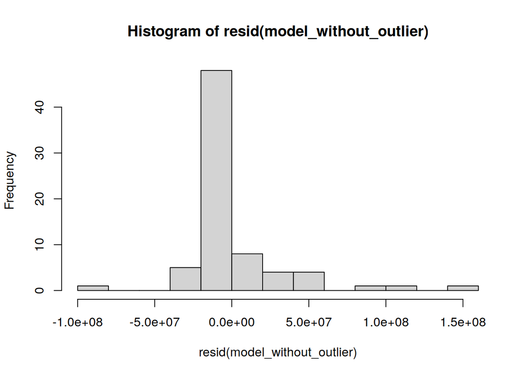

since there is a single country causing havoc, we can just yeet it from our dataset, and analyze the other countries without it. this gives us a more meaningful view of the countries.

```
##
## Call:
## lm(formula = raw_population ~ raw_area, data = nettle_filtered_1)
##
## Residuals:
##       Min        1Q    Median        3Q       Max
## -80227470 -14152889  -9257811   1313046 152223896
##
## Coefficients:
##              Estimate Std. Error t value Pr(>|t|)
## (Intercept) 1.329e+07  4.344e+06   3.059 0.003133 **
## raw_area    1.086e+01  2.690e+00   4.039 0.000134 ***
## ---
## Signif. codes:  0 '***' 0.001 '**' 0.01 '*' 0.05 '.' 0.1 ' ' 1
##
## Residual standard error: 31570000 on 71 degrees of freedom
## Multiple R-squared:  0.1868, Adjusted R-squared:  0.1754
## F-statistic: 16.31 on 1 and 71 DF,  p-value: 0.0001342
```

we can now see an even better statistical significance for the area, even without centering it.

```
##
## Call:
## lm(formula = raw_population ~ centered_raw_area, data = nettle_filtered_1)
##
## Residuals:
##       Min        1Q    Median        3Q       Max
## -80227470 -14152889  -9257811   1313046 152223896
##
## Coefficients:
##                    Estimate Std. Error t value Pr(>|t|)
## (Intercept)       2.287e+07  3.696e+06   6.188 3.49e-08 ***
## centered_raw_area 1.086e+01  2.690e+00   4.039 0.000134 ***
## ---
## Signif. codes:  0 '***' 0.001 '**' 0.01 '*' 0.05 '.' 0.1 ' ' 1
##
## Residual standard error: 31570000 on 71 degrees of freedom
## Multiple R-squared:  0.1868, Adjusted R-squared:  0.1754
## F-statistic: 16.31 on 1 and 71 DF,  p-value: 0.0001342
```

we have a t-value of 4.04 now for the area, which is statisically much stronger than before. we have also increased the t-value for the intercept, meaning the size of an average country is statistically much more meaningful than before. the p-values are extremely low too, meaning there is a very strong relationship between our variables (aka it’s super unlikely the values have occurred due to random chance).

## (f2) ignoring 14 outliers

```
##  [1] "India"        "Australia"    "Indonesia"    "Bangladesh"   "Nigeria"
##  [6] "Brazil"       "Libya"        "Saudi Arabia" "Sudan"        "Vietnam"
## [11] "Algeria"      "Philippines"  "Chad"         "Mauritania"
```

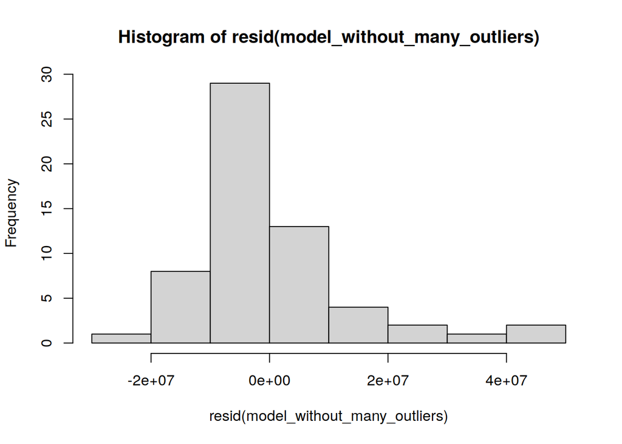

```
##
## Call:
## lm(formula = raw_population ~ centered_raw_area, data = nettle_filtered_outliers)
##
## Residuals:
##       Min        1Q    Median        3Q       Max
## -21948964  -7014664  -1641916   4256789  42515171
##
## Coefficients:
##                    Estimate Std. Error t value Pr(>|t|)
## (Intercept)       2.189e+07  2.116e+06  10.343 8.75e-15 ***
## centered_raw_area 2.126e+01  3.448e+00   6.166 7.26e-08 ***
## ---
## Signif. codes:  0 '***' 0.001 '**' 0.01 '*' 0.05 '.' 0.1 ' ' 1
##
## Residual standard error: 13150000 on 58 degrees of freedom
## Multiple R-squared:  0.3959, Adjusted R-squared:  0.3855
## F-statistic: 38.02 on 1 and 58 DF,  p-value: 7.255e-08
```

while ignoring the top 14 outliers is kind of a big deal, the p-value of 7.2e-08 is incredibly low!